# Weekly Report 2/15

Erin Feichtinger

February 15, 2016

It’s been two weeks since Gordon and I last met because I came down with a cold that lasted a week and to top it off, I got the worst migraine in recent memory last Friday that put me in bed all afternoon. Anyway, here is a summary from when we last left off on February 2, 2016.

My last report included some figures with r (intrinsic rate of growth) as a function of T and R0. Gordon had some suggestions on how to improve the figures so we are seeing real patterns and not artifacts in the graphs.

## Changes suggested

- Remove points where r = 0 (R0 = 1)
- Rescale axes
- Change dimensions
- Change symbol type
- Adjust color bar so it is the same length for T and R0
- Increase sampling intensity in g if needed, see how new symbols look

I did rescale the axes (which takes care of problem 2) and the dimensions. The package that I am using for the figures does not appear to have an option for changing the symbol. The arguments to change symbol type from plot in base R do not work with the function (although some arguments from plot do work with scatter2D). There could be another function in the package plot3D that could be useful.

I asked Gordon a few days after our meeting for some clarification, especially on the last three suggestions. He suggested using a period/dot for symbol type. In base plot, it’s pch = “.”. He says increase the sampling intensity of points like having even smaller increments in g. But, this problem could be solved with changing the symbols. The current dots overlap each other and could be obscuring patterns.

I could try using other packages with 3D plotting functions or try persp-based 3D plots. I don’t know how useful using 2D plots are to display the results.

Previously, I had used the function scatter2d in package plot3D but I could not change the symbol type from the open dots. From what I understand, that is how the scatter2d plot is set up (to use open points). I couldn’t find a way to change it after searching for some time online so I moved on to trying different functions for making graphics. I made a few 2d plots using the base plot function in r where it is easy to change the point type. I also used another function scatterplot3d (which is also the package name) that uses arguments from plot.

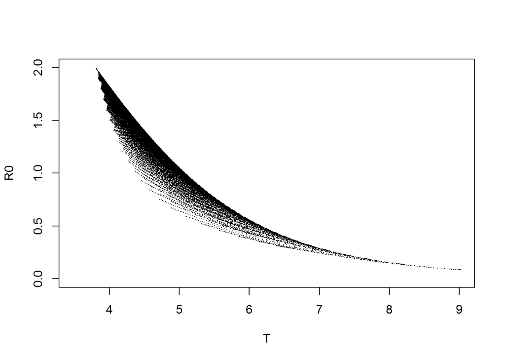

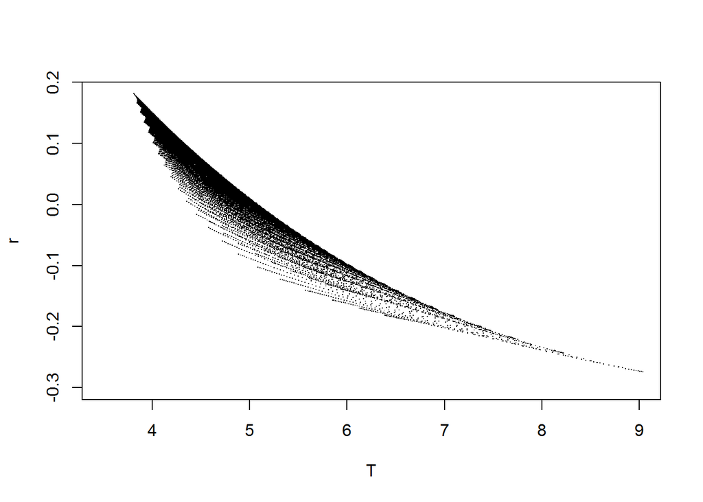

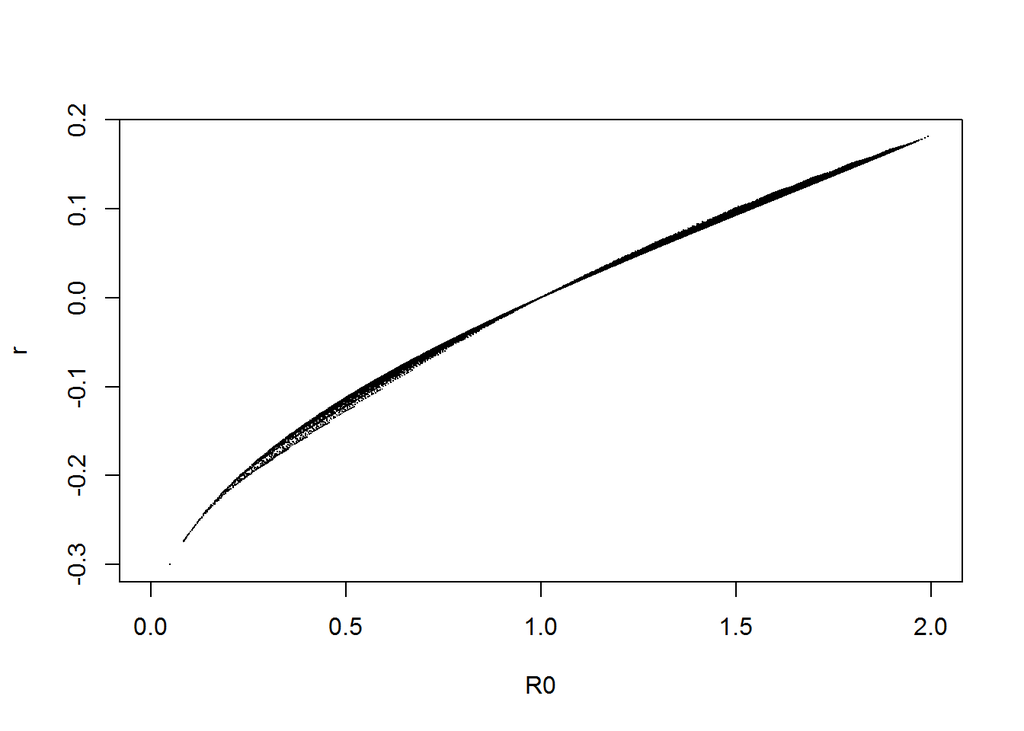

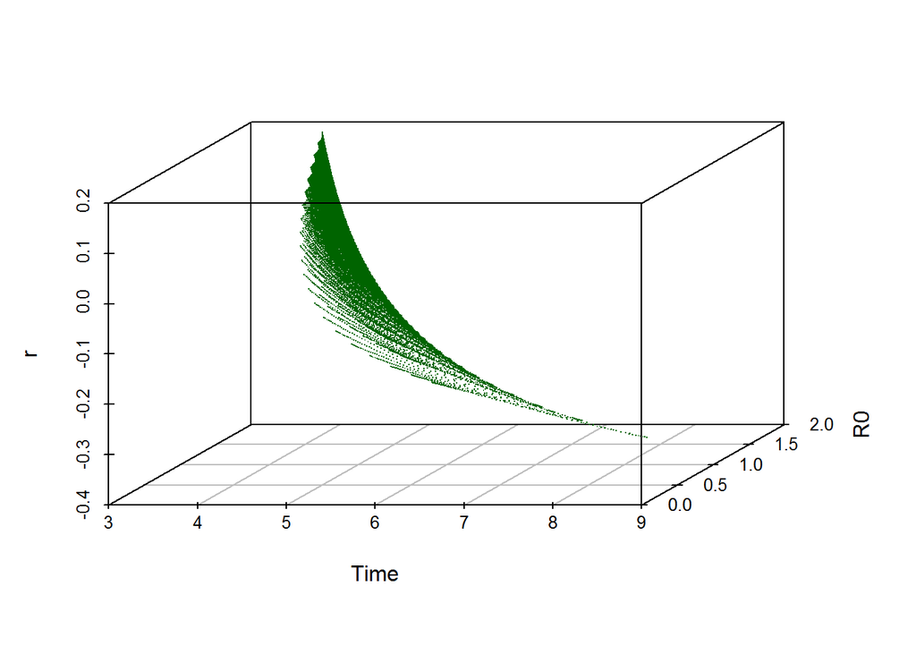

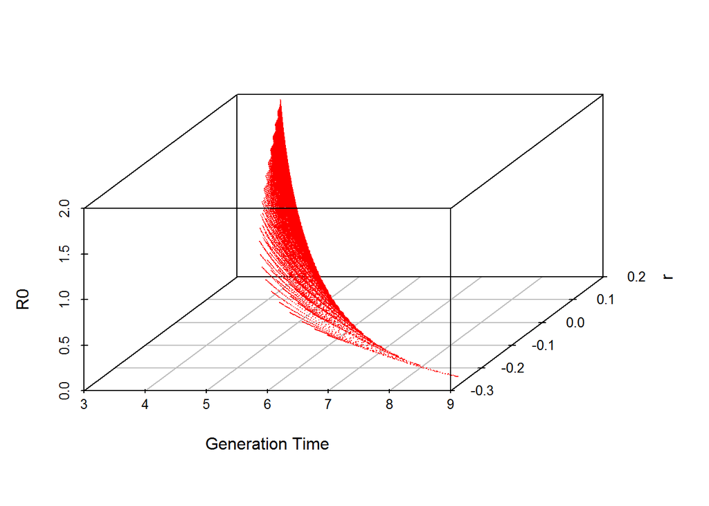

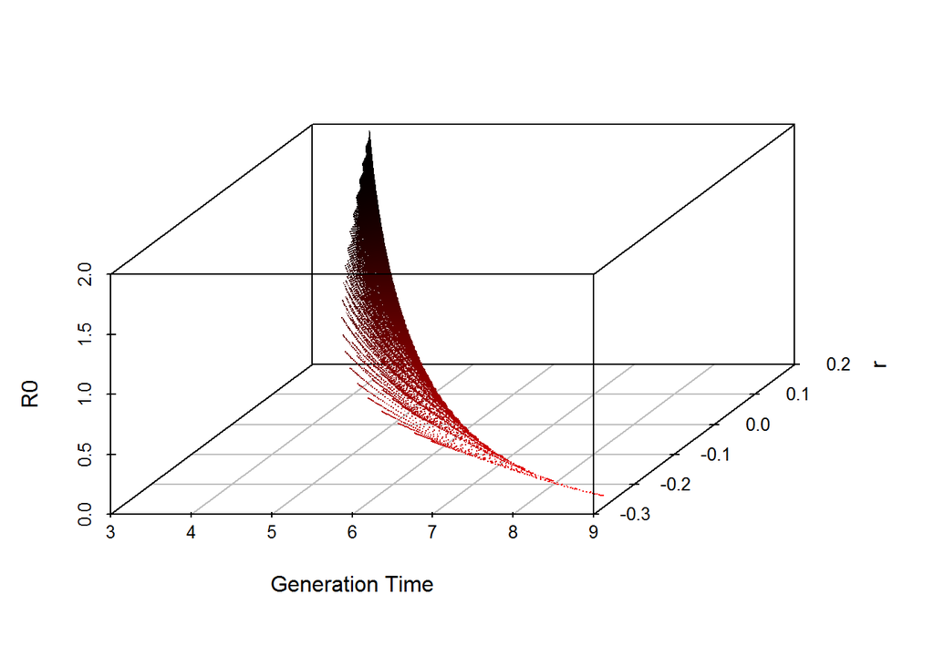

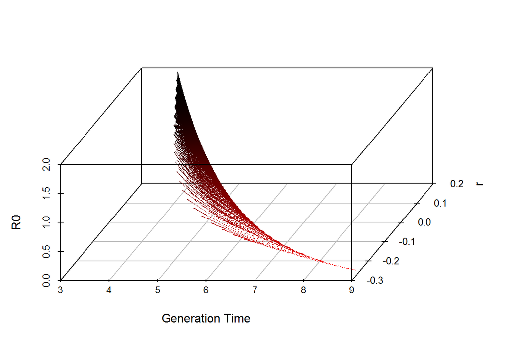

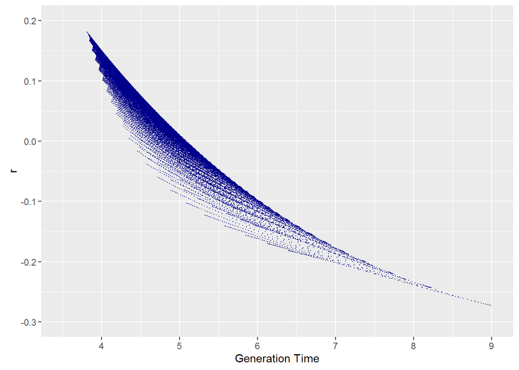

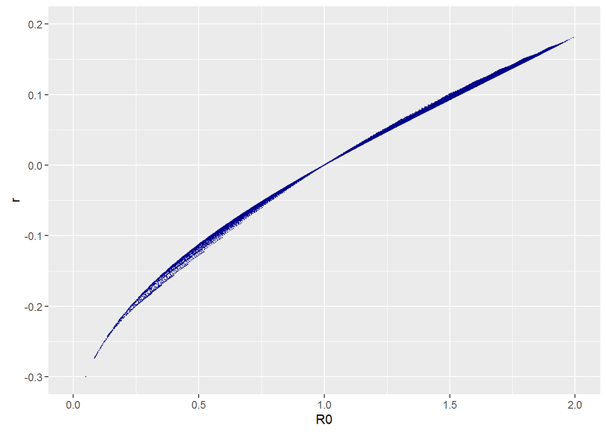

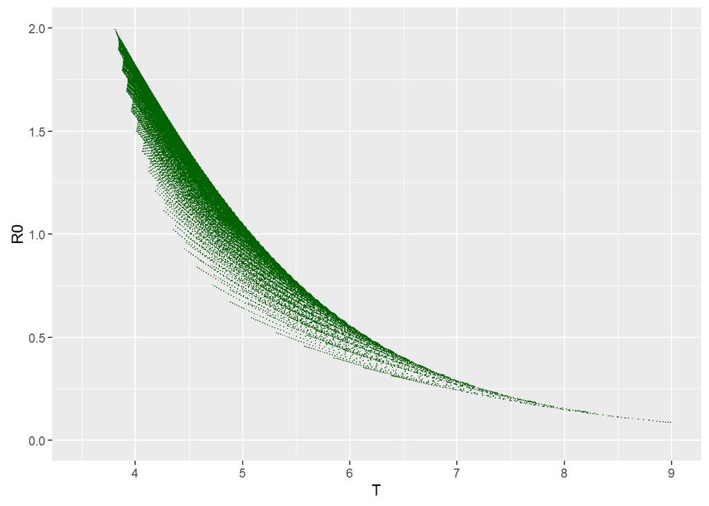

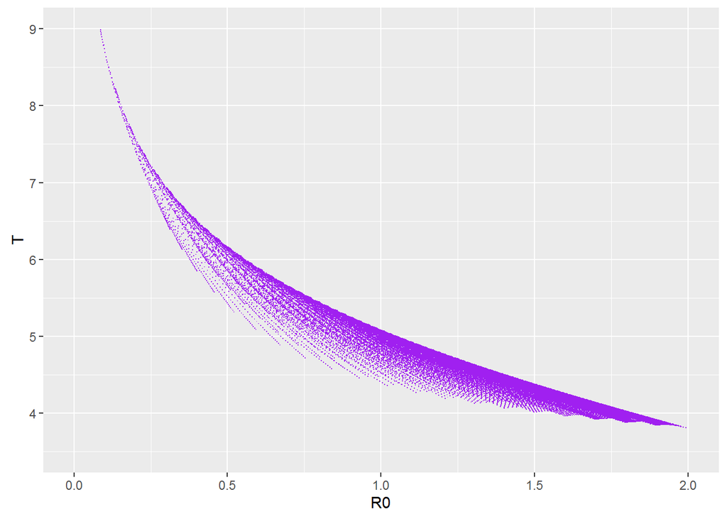

I have another draft that I sent to Gordon and I hope we can start to go through it soon. My main goal for the meeting is to talk about the writing if Gordon has had a chance to read it. I updated the results section several weeks ago so we should be at least able to talk about that. I just sent the most recent version which has a discussion added to it.

General plan for next week

1. Make suggested changes to manuscript
2. Work on graphs
3. Jay survival models
4. Anything else deemed necessary